# Introduction to Statistical Learning

2025-10-01

## Transitioning to Part II: Supervised Learning

**Part I Recap:** We built our foundation

- Data wrangling with `dplyr` and `tidyr`
- Exploratory data analysis with `ggplot2`
- Feature engineering and advanced wrangling

**Part II Focus:** Now we use these skills to build predictive models

- Today marks our transition from *preparing data* to *modeling data*
- The cleaned datasets and features we create in Part I become the inputs for the statistical learning methods in Part II

## What is Statistical Learning?

- A framework to model the relationship between variables.
- The goal is to find a function, \(f\), that accurately models an output variable (\(Y\)) from a set of input variables (\(X\)).
- It’s a fundamental part of **data science and machine learning**, used for both prediction and understanding.

## Why Do We Care?

- **Prediction:**
  - Predict the value of \(Y\) for new, unseen data.
  - Accuracy is the most important metric.
  - **Examples:** Predicting loan defaults or house prices.
- **Inference:**
  - Understand the relationship between \(X\) and \(Y\).
  - Interpretability is crucial.
  - **Example:** Understanding how interest rates impact consumer spending.

## The Model-Building Process: The Equation

- The true relationship is described by:

  \(Y = f(X) + \epsilon\)
- **Components:**
  - **\(Y\)**: The **response**, **dependent variable**, or **output**.
  - **\(X\)**: The **predictors**, **features**, or **independent variables**.
  - **\(f\)**: The **systematic function** we learn to model the relationship.
  - **\(\epsilon\)**: The **random error** or **noise** (irreducible error). This part can’t be reduced by our model.

## Supervised vs. Unsupervised Learning

- **Supervised Learning:**
  - Uses a known, labeled response (\(Y\)) and predictors (\(X\)).
  - “Supervision” comes from having the answers.
  - **Goal:** Predict \(Y\) from new \(X\) data.
  - **Examples:** Linear Regression, Decision Trees.
- **Unsupervised Learning:**
  - Uses only predictors (\(X\)), with no labeled response (\(Y\)).
  - **Goal:** Discover hidden structures or groupings in the data.
  - **Examples:** Clustering, Principal Component Analysis (PCA).

## Supervised Learning: Regression

- **Regression** is a supervised task.
- The response variable (\(Y\)) is **quantitative** or **continuous**.
- **Examples:**
  - Predicting a house’s price.
  - Estimating a patient’s blood pressure.
  - Forecasting next month’s sales revenue.

## Supervised Learning: Classification

- **Classification** is a supervised task.
- The response variable (\(Y\)) is **qualitative** or **categorical**.
- **Examples:**
  - Classifying a tumor as benign or malignant.
  - Determining if an email is “spam” or “not spam.”
  - Approving or denying a loan.

## Unsupervised Learning: Clustering

- **Clustering** is a classic unsupervised task.
- The goal is to group observations into subgroups based on similarity.
- No prior information about the groups is needed.
- **Examples:** Grouping planets by characteristics, or songs by musical features.

## Model Flexibility

- **Model Flexibility** is the range of shapes a model can take on to fit the function \(f\).
- **Highly Flexible Models:**
  - Can capture complex, non-linear relationships.
  - **Examples:** Splines, Deep Learning models.
- **Less Flexible Models:**
  - Limited to a specific functional form (e.g., a straight line).
  - **Examples:** Linear Regression, Logistic Regression.

## Model Interpretability

- **Model Interpretability** is how easily we can understand a model’s predictions.
- **High Interpretability:**
  - We can easily see each variable’s impact.
  - Coefficients in a linear model show a clear relationship.
  - **Examples:** Linear Regression, Simple Decision Trees.
- **Low Interpretability:**
  - Difficult to understand the model’s complex interactions.
  - These models are often called “black boxes.”
  - **Examples:** Deep Neural Networks, Random Forests.

## The Flexibility vs. Interpretability Trade-Off

- **The Trade-off:** More flexibility often means less interpretability.
- **The Choice:**
  - **For Inference:** Use an interpretable, less flexible model to understand relationships.
  - **For Prediction:** Use a more flexible model for the most accurate predictions.
- **Examples:**
  - **Interpretable:** An economist uses **linear regression** to explain how interest rates affect GDP. The goal is to explain *why* it changes.
  - **Flexible:** A company uses a **Random Forest** to predict which users will click an ad. The goal is the most accurate prediction; they don’t care *why* the user clicks.

## The Bias-Variance Trade-off

- A critical concept in statistical learning.
- Describes a model’s error in terms of **bias** and **variance**.
- You almost always have to trade one for the other.

## Bias and Variance: A Visual Analogy

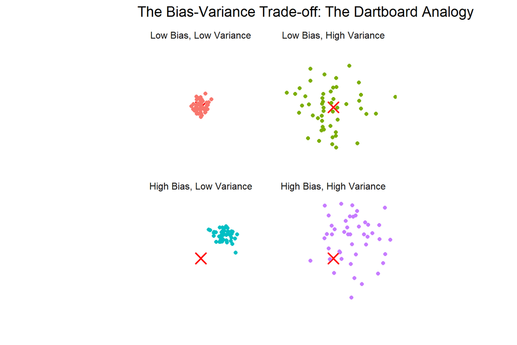

## Live Example: The Bias-Variance Trade-off

- This example simulates data with a non-linear relationship.
- We fit three models with varying flexibility to demonstrate bias and variance.

## Case 1: High Bias (Underfitting)

- This model is too simple to capture the non-linear pattern.
- The straight line is a **high-bias** model that consistently misses the true relationship.
- This results in a large error, also known as **underfitting**.

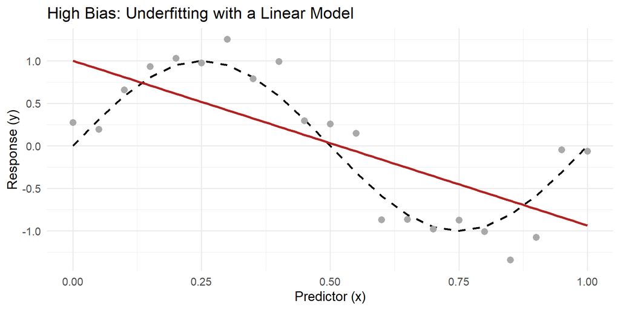

## Case 2: Optimal Flexibility

- This model strikes a good balance, capturing the true pattern well.
- It has **low bias** because it fits the true function closely.
- Its **variance** is controlled because it doesn’t fit the random noise.

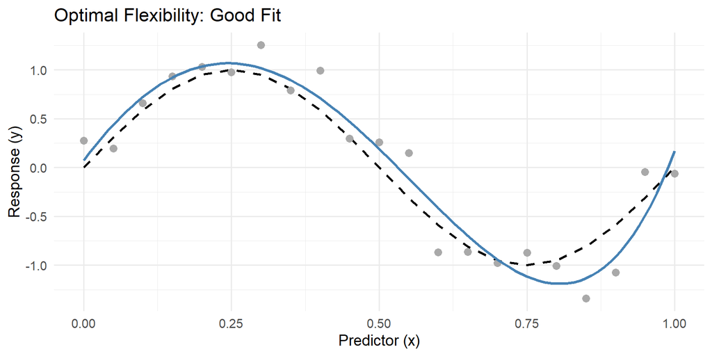

## Case 3: High Variance (Overfitting)

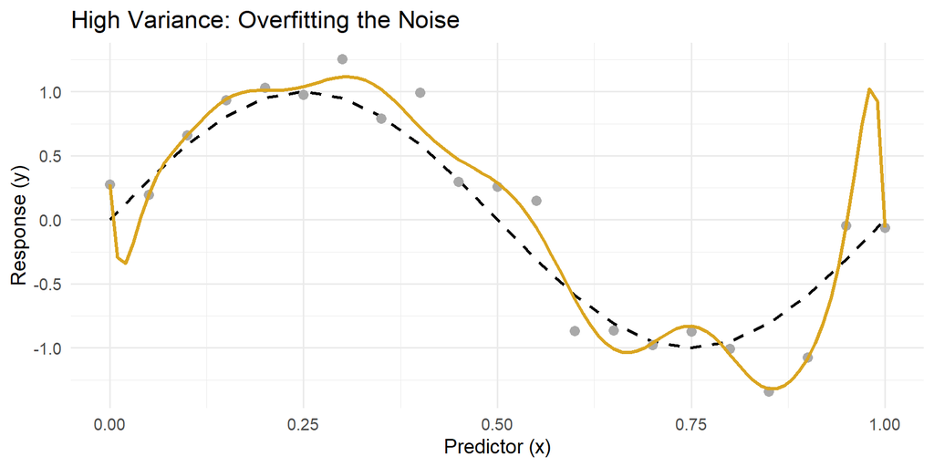

## Visualizing the Trade-off

- This plot visually represents the three scenarios.
- The dashed line is the true relationship, and the colored lines are the models’ predictions.
- You can see how the models with low and high flexibility perform compared to the optimal one.

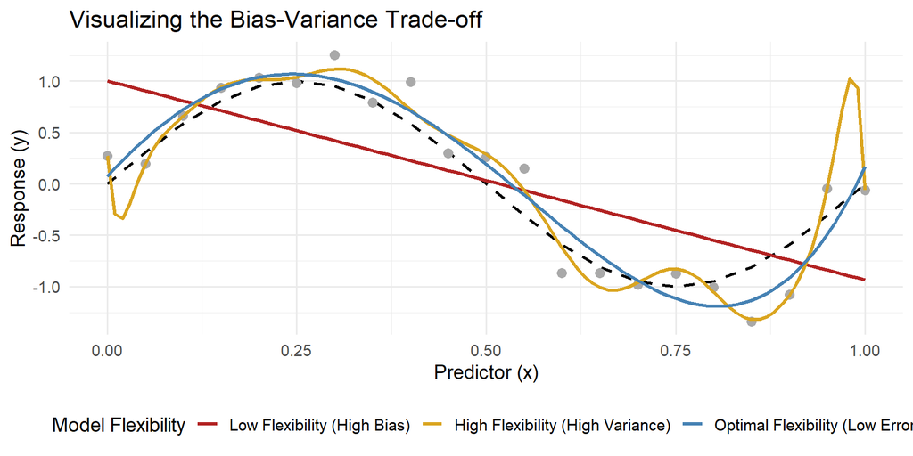

## The U-Shaped Curve

- **Total Error** for a model is: \(Total Error = Bias^2 + Variance + Irreducible Error\)
- As a model becomes more complex:
  - **Bias** decreases, **Variance** increases.
- **Irreducible Error** is inherent noise and cannot be reduced.
- Optimal complexity is at the bottom of the curve, where total error is minimized.

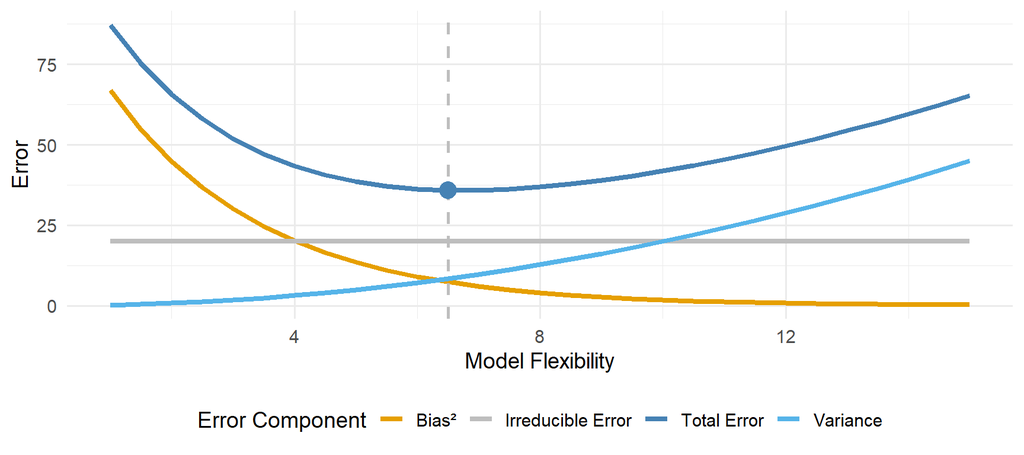

## Overfitting

- **Overfitting** happens when a model is too flexible (high variance).
- The model fits the training data perfectly, including the random noise.
- This leads to poor performance on new, unseen data.

## The Role of Training vs. Test Data

- To combat overfitting, we split data into two sets:
  - **Training Set:** Used to build the model.
  - **Test Set:** Used to evaluate the model’s performance on unseen data.
- Test set performance is a better indicator of true predictive power.

## Summary of Key Concepts

- **Statistical learning:** A set of tools to find structure in data.
- **Supervised vs. Unsupervised Learning:** Presence or absence of a response variable.
- **Flexibility vs. Interpretability:** A key model selection trade-off.
- **The Bias-Variance Trade-off:** The balance between model simplicity and complexity.
- **Overfitting:** The primary danger of overly flexible models.

An important part of Data Science is matching the right model to the right situation